# eMOLT Update

*eMOLT Update 2025-12-05*

## Weekly Recap

This week, I’m out to sea supporting the Bottom Trawl Survey aboard the NOAA Ship Henry B. Bigelow, so the update will be pretty short.

This week, the eMOLT fleet recorded 112 tows of sensorized fishing gear totaling 3000 sensor hours underwater.

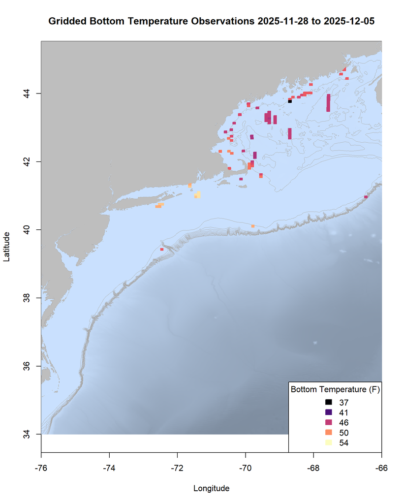

> *Figure 1 – FISHBOT bottom temperature records from the past week. The data are available on the [Commercial Fisheries Research Foundation ERDDAP](https://erddap.ondeckdata.com/erddap/tabledap/fishbot_realtime.html) and an interactive visualization is available at the [Cape Cod Ocean Watch](https://ccocean.whoi.edu/index.html) dashboard hosted by Woods Hole Oceanographic Institution. FISHBOT aggregates data provided by participants in eMOLT, the CFRF Lobster and Jonah Crab Research Fleet, the CFRF Shelf Research Fleet, the Cape Cod Commercial Fishermen’s Alliance Cape Cod Oceanographic Research Fleet, the Maine Coast Fishermen’s Association Fisheries Ocean Data Program, MassDMF Cape Cod Bay Study Fleet, the Northeast Fisheries Science Center Study Fleet, and the Northeast Fisheries Science Center Ecosystem Monitoring Surveys*

### Regional Dissolved Oxygen Loggers

We will be organizing ways to return the dissolved oxygen loggers over the next few weeks. For vessels on Cape Cod or the South Shore, we’ll try to pick the sensors up from you. For vessels up in Maine or down in New Jersey, we’ll send you a prepaid shipping label so you can send them back for recalibration and battery replacement.

### Bottom Temperature Forecast Performance

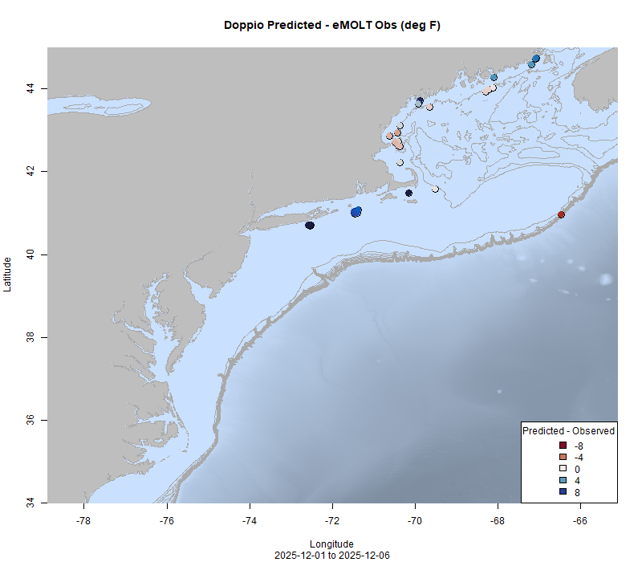

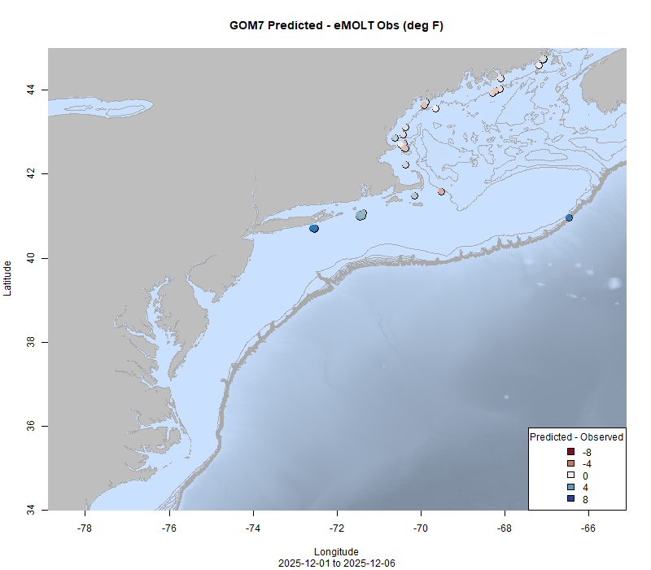

> *Figure 4 – Comparisons between bottom temperatures predicted by two ocean forecasting models and observations from the eMOLT fleet. Blue dots show where the observations were cooler than the forecast and red dots show where the observations were warmer than the forecast. White dots show areas where the observations and forecasts agreed. On the left is the comparison with the Doppio model and on the right is the comparison with the NECOFS model (GOM7).*

### Disclaimer

The eMOLT Update is NOT an official NOAA document. Mention of products or manufacturers does not constitute an endorsement by NOAA or Department of Commerce. The content of this update reflects only the personal views of the authors and does not necessarily represent the views of NOAA Fisheries, the Department of Commerce, or the United States.

All the best,

-George